# Regression Model

Tejus

29/09/2020

## Prediction of Child’s height

- Suppose we want to predict the children’s height using parent’s height. We can train a model using **Galton data**.
- Let’s look at the marginal (parents disregarding children and children disregarding parents) distributions first.

```r
data(galton)
long <- melt(galton)
```

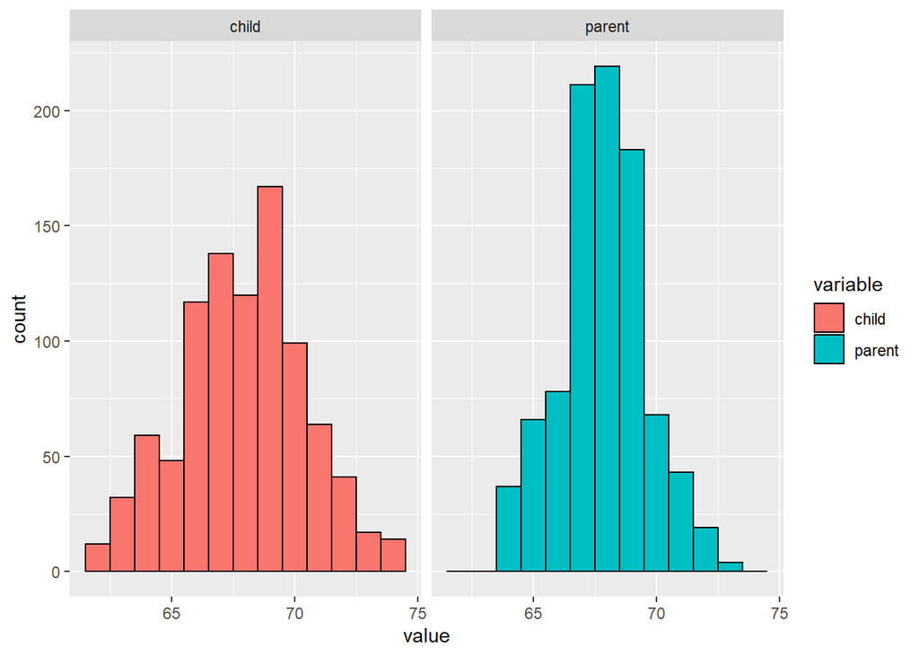

```r
# Marginal Histograms of Parents & Child's height
g <- ggplot(data = long, aes(x=value, fill=variable))
g <- g + geom_histogram(color = "black", binwidth = 1) + facet_grid(.~variable)
g
```

## Finding the best prediction of child’s height without any other info (Parent’s height here)

- Best predictor is the middle
- One definition for the middle ($\mu$) is, if $Y_i$ is the height of child $i$ for $i = 1, \ldots, n = 928$, then the middle is the value of $\mu$ that minimizes
  $$\sum_{i=1}^n (Y_i - \mu)^2$$
- This is physical center of mass of the histogram.
- You might have guessed that the answer $\mu = \bar Y$.

## Exercise to find the center of mass using manipulate in RStudio

Code `Center_Of_Mass.R`

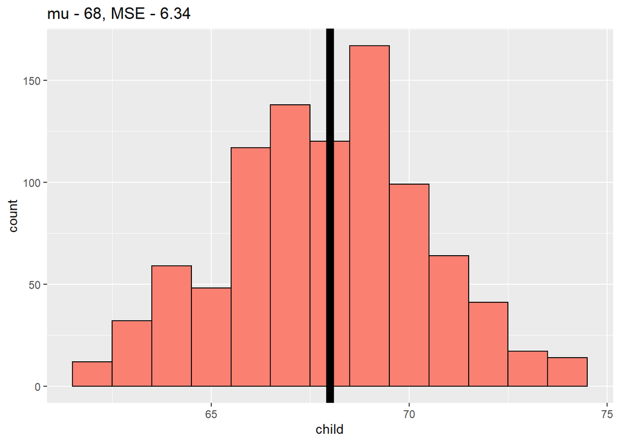

```r
      mu = 68
      mse <- mean((galton$child - mu)^2)
      g <- ggplot(galton, aes(x = child)) + geom_histogram(fill = "salmon", colour = "black", binwidth = 1) + geom_vline(xintercept = mu, size = 3)
      g <- g + ggtitle(paste("mu - ", mu, ", MSE - ", round(mse,2), sep = ""))
      g
```

After finding the mu which minimized the MSE (Mean squared error) we got
$$\mu = 68$$
. And the mean of thr child data is 68.0884698. Thus it’s proved that the best predictor is the middle.

## Ordinary least squares (OLS) : Background

- Workhorse of statistics.
- **Centering the random variables** by subtracting the mean from each data point.
  $$\tilde X_i = X_i - \bar X.$$
- The mean of the $\tilde X_i$ is 0.
- **The empirical variance** is
  $$S^2 = \frac{1}{n-1} \sum_{i=1}^n (X_i - \bar X)^2 = \frac{1}{n-1} \left( \sum_{i=1}^n X_i^2 - n \bar X ^ 2 \right)$$
- **Scaling the data**: Divide every observation by the standard deviation ($X_i / s$) the resulting data will have `sd = 1`
- **Normalized data** : The data defined by
  $$Z_i = \frac{X_i - \bar X}{s}$$
  have emperical mean zero & standard deviation 1.
- Normalised data have center at mean & have units equal to standard deviations away from the mean of the original data.
  - Example, a value of 2 from normalized data means that data point was two standard deviations larger than the mean.

### Empirical covariance

- Consider now when we have pairs of data, $(X_i, Y_i)$.
- Their **empirical covariance** is
  $$Cov(X, Y) =
  \frac{1}{n-1}\sum_{i=1}^n (X_i - \bar X) (Y_i - \bar Y)
  = \frac{1}{n-1}\left( \sum_{i=1}^n X_i Y_i - n \bar X \bar Y\right)$$
- The **correlation** is defined is
  $$Cor(X, Y) = \frac{Cov(X, Y)}{S_x S_y}$$
  where $S_x$ and $S_y$ are the estimates of standard deviations for the $X$ observations and $Y$ observations, respectively.

**Covariance has units of X & Y. So when we divide it by standard deviation of both we get an unitless quantity as Correlation.**

### Facts about correlation

- $Cor(X, Y) = Cor(Y, X)$
- $-1 \leq Cor(X, Y) \leq 1$
- $Cor(X,Y) = 1$ and $Cor(X, Y) = -1$ only when the $X$ or $Y$ observations fall perfectly on a positive or negative sloped line, respectively.
- $Cor(X, Y)$ measures the strength of the linear relationship between the $X$ and $Y$ data, with stronger relationships as $Cor(X,Y)$ heads towards -1 or 1.
- $Cor(X, Y) = 0$ implies no linear relationship.

## Ordinary least squares (OLS) : Finding the best prediction of child’s height with Parent’s height.

### Fitting the best line

- Let $Y_i$ be the $i^{th}$ child’s height and $X_i$ be the $i^{th}$ (average over the pair of) parents’ heights.
- Consider finding the best line to predict
  - Child’s Height = $\beta_0$ + Parent’s Height $\beta_1$
- Use least squares we decide the final best fitting line by minimizing following condition
  $$\sum_{i=1}^n \{Y_i - (\beta_0 + \beta_1 X_i)\}^2$$
- **Boils down to estimating the unknowns :** $\beta_0$ & $\beta_1$

## Results & their consequences :

**Result** The least squares model fit to the line $Y = \beta_0 + \beta_1 X$ through the data pairs $(X_i, Y_i)$ with $Y_i$ as the outcome obtains the line $Y = \hat \beta_0 + \hat \beta_1 X$ where
$$\hat \beta_1 = Cor(Y, X) \frac{Sd(Y)}{Sd(X)} ~~~ \hat \beta_0 = \bar Y - \hat \beta_1 \bar X$$

- **Consequences of results**
  - $\hat \beta_1$ has the units of $Y / X$, $\hat \beta_0$ has the units of $Y$.
  - The line passes through the point $(\bar X, \bar Y$) ;
    - Proof; Rearrange the eq. of $\beta_0$ to $\bar Y = \hat \beta_0 + \hat \beta_1 \bar X$).
    - Once we plug in value of $\bar X$ into the equation of the fitted line we get $\bar Y$ out.
  - The slope of the regression line with $X$ as the outcome and $Y$ as the predictor is $Cor(Y, X) Sd(X)/ Sd(Y)$.
  - The slope of regression with the intercept (original data) is the equal to the slope you would get if you **centered the data (removed the intercept)**, $(X_i - \bar X, Y_i - \bar Y)$, and **did regression through the origin**.
  - If you normalized the data, $\{ \frac{X_i - \bar X}{Sd(X)}, \frac{Y_i - \bar Y}{Sd(Y)}\}$, the slope is $Cor(Y, X)$.

### Regression in R

**Manually**

```r
y = galton$child
x = galton$parent

# Slope
beta1 <- cor(y, x)*(sd(y)/sd(x))
beta0 <- mean(y) - (beta1*mean(x))

# Coefficients are
c(beta0, beta1)
```

```
## [1] 23.9415302  0.6462906
```

```r
# Using lm()
coef(lm(y~x))
```

```
## (Intercept)           x
##  23.9415302   0.6462906
```

### Statement 1 : Slope of linear regression for mean centered values = Slope of regression through the origin for mean centered values

```r
# Regression through the origin**
xc = x - mean(x)
yc = y - mean(y)

# Slope of regression through the origin for mean centered data
beta1 <- sum(yc *xc) / sum(xc^2)
  # Or just beta1 <- coef(lm(yc~xc-1))

# results
c(beta1, coef(lm(yc~xc))[2])
```

```
##                  xc
## 0.6462906 0.6462906
```

### Statement 2 : Slope of the Normalized values = Correlation (X,Y)

```r
xn = (x - mean(x)) / sd(x)
yn = (y - mean(y)) / sd(y)

# Slope of the Normalized values
beta1 = cor(yn,xn) * (sd(xn)/ sd(yn))

# results
c(beta1, cor(xn, yn), cor(y,x))
```

```
## [1] 0.4587624 0.4587624 0.4587624
```

### Plotting a regression line

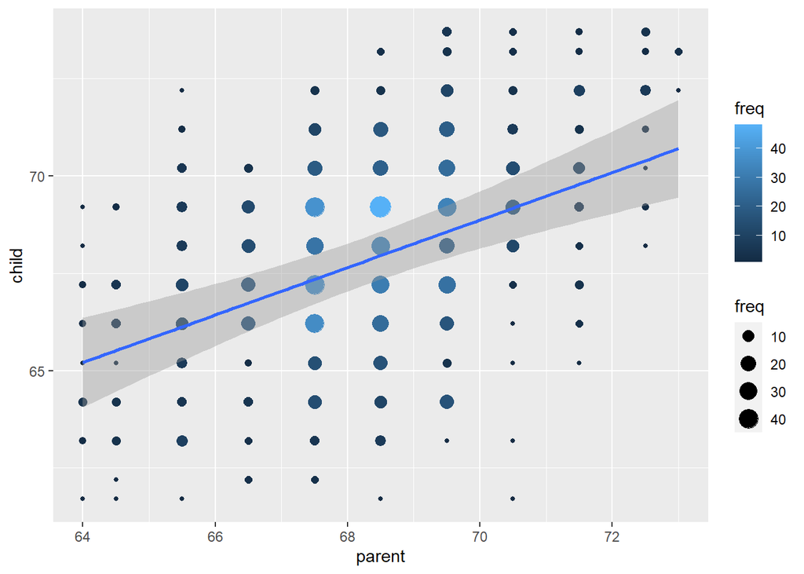

```r
freqData <- as.data.frame(table(galton$child, galton$parent))
names(freqData) <- c("child", "parent", "freq")
freqData$child <- as.numeric(as.character(freqData$child))
freqData$parent <- as.numeric(as.character(freqData$parent))

g <- ggplot(filter(freqData, freq > 0), aes(x = parent, y = child))
g <- g + geom_point(aes(color = freq, size = freq, show_guide = FALSE))
g <- g + geom_smooth(method = "lm", formula = y~x)
g
```

### Regression to the Mean

Here is a fundamental question. Why is it that the children of tall parents tend to be tall, but not as tall as their parents? Why do children of short parents tend to be short, but not as short as their parents? Conversely, why do parents of very short children, tend to be short, but not a short as their child? And the same with parents of very tall children?

These phenomena are all examples of so-called **regression to the mean**.

- Regression to the mean, was invented by Francis Galton in the paper “Regression towards mediocrity in hereditary stat” The Journal of the Anthropological Institute of Great Britain and Ireland , Vol. 15, (1886).
- The idea served as a foundation for the discovery of linear regression.

## Statistical linear regression models

Estimation is useful, but we also need to know how to extend our estimates to a population. This is the process of statistical inference.

- Consider developing a probabilistic model for linear regression
  $$Y_i = \beta_0 + \beta_1 X_i + \epsilon_{i}$$
  Note : By adding the iid Gaussian errors we make it a statistical model.
- Here the $\epsilon_{i}$ are assumed iid $N(0, \sigma^2)$.
- Expected values of response given the particular values of regressor is given by, $E[Y_i ~|~ X_i = x_i] = \mu_i = \beta_0 + \beta_1 x_i$
- Variance of the response at any particular value of regressor, $Var(Y_i ~|~ X_i = x_i) = \sigma^2$.

Note : This expected value and variance is around the regression line (for each of the response variable) and not for the whole response variable $Y_i$ as such. Imagine each data point coming from it’s own distribution with expected value & variance parameters defined by above formulas.

### Interpreting regression coefficients for statistical models.

- Interpretation of the coefficients is an important thing to consider if the researcher is interested to understand the mechanism of the system under study.

#### Intercept

- Since response $Y$ at $X = 0$ is not meaningful in all cases, we shift the values of X by some constant $a$.
  $$Y_i = \beta_0 + \beta_1 X_i + \epsilon_i$$
  $$= \beta_0 + a \beta_1 + \beta_1(X_i - a) + \epsilon_i$$
  $$= \tilde \beta_0 + \beta_1 X_i + \epsilon_i$$
- Thus we can see that if we shift our regressor by a constant, we get a new regression line, with the same slope but with different intercept. Very common constant is $\bar X$.
- Your intercept will be then **interpreted as Expected value of response at the average values of X’s**.

#### Slope

- $\beta_1$ is the expected change in response for a 1 unit change in the predictor
  $$E[Y ~|~ X = x+1] - E[Y ~|~ X = x] =
  \beta_0 + \beta_1 (x + 1) - (\beta_0 + \beta_1 x ) ~=~ \beta_1$$
- Consider the impact of changing the units of $X$.
  $$Y_i = \beta_0 + \beta_1 X_i + \epsilon_i
  = \beta_0 + \frac{\beta_1}{a} (X_i a) + \epsilon_i
  = \beta_0 + \tilde \beta_1 (X_i a) + \epsilon_i$$

**In other words multiplication of a regression variable $X$ by factor ‘a’ results in dividing the coeff by factor ‘a’**

- This is especially usefull in changing the scale of data and interpreting the new coefficients.

### Using regression coeficients for prediction

- If we would like to guess the outcome at a particular value of the predictor, say $X$, the regression model guesses $\hat \beta_0 + \hat \beta_1 X$
- Note that at the observed value of $X$s, we obtain the predictions $\hat \mu_i = \hat Y_i = \hat \beta_0 + \hat \beta_1 X_i$
- Remember that least squares minimizes $\sum_{i=1}^n (Y_i - \mu_i)$ for $\mu_i$ expressed as points on a line.

### Example

- Diamond dataset

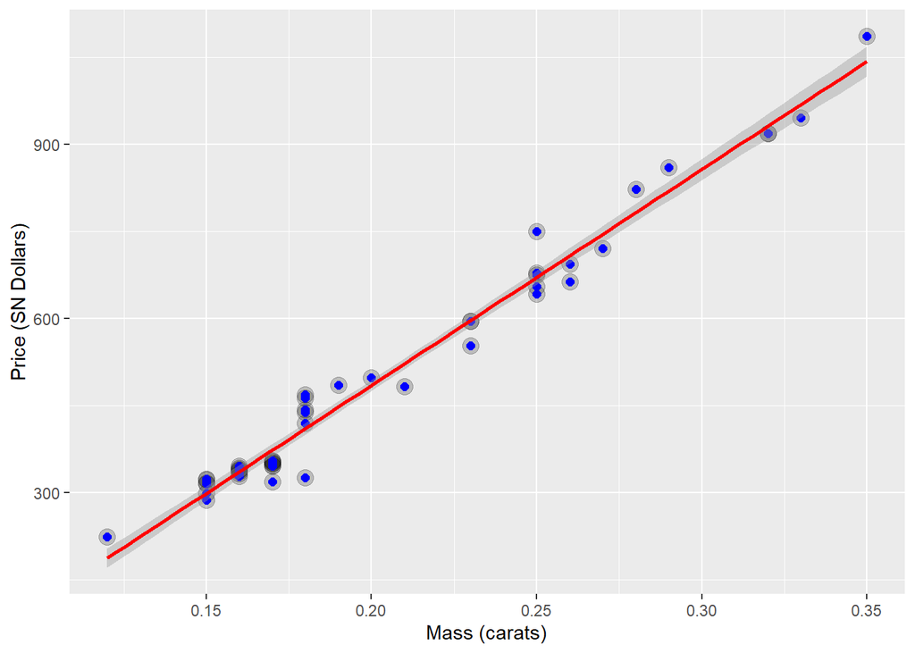

```r
library(UsingR); data(diamond)
g <- ggplot(data = diamond, aes(x= carat, y = price)) + xlab("Mass (carats)") + ylab("Price (SN Dollars)")
g <- g + geom_point(size = 4, alpha = 0.2) + geom_point(size = 2, colour = "blue")
g <- g + geom_smooth(method = "lm", colour = "red")
g
```

## Fitting the linear regression model

```r
fit <- lm(price ~ carat, data = diamond)
coef(fit)
```

```
## (Intercept)       carat
##   -259.6259   3721.0249
```

- We estimate an expected 3721.02 (SIN) dollar increase in price for every carat increase in mass of diamond.
- The intercept -259.63 is the expected price of a 0 carat diamond.
- Since 0 carat diamond doesn’t exist we can mean center the values of x.

## Getting a more interpretable intercept

```r
fit1 <- lm(price ~ I(carat - mean(carat)), data= diamond)
coef(fit1)
```

```
##            (Intercept) I(carat - mean(carat))
##               500.0833              3721.0249
```

- Again as mentioned above the slope remains the same just the intercept changes. Thus 500.1 is the expected price for the average sized diamond of the data (0.2041667 carats).

## Changing scale

- A one carat increase in a diamond is pretty big, what about changing units to 1/10th of a carat?
- We can just do this by just dividing the coeficient by 10.
  - We expect a 372.102 (SIN) dollar change in price for every 1/10th of a carat increase in mass of diamond.
- Showing that it’s the same if we rescale the Xs and refit

```r
fit3 <- lm(price ~ I(carat * 10), data = diamond)
coef(fit3)
```

```
##   (Intercept) I(carat * 10)
##     -259.6259      372.1025
```

- Proof given above in Interpretaion of coefficients section.

## Residuals & residual variation

Residuals represent variation left unexplained by our model. We emphasize the difference between residuals and errors. **The errors are unobservable true errors from the known coefficients, while residuals are the observable errors from the estimated coefficients.** In a sense, the residuals are estimates of the errors.

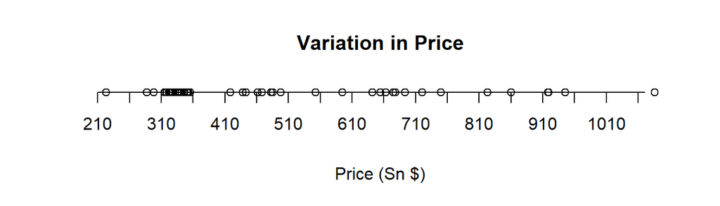

[figure not shown]

- Residual, the between the observed and predicted outcome $e_i = Y_i - \hat Y_i$
  - The vertical distance between the observed data point and the regression line
- Least squares minimizes $\sum_{i=1}^n e_i^2$
- The $e_i$ can be thought of as estimates of the $\epsilon_i$.

### Properties of residuals

- Expected value, $E[e_i] = 0$
- If an intercept is included, $\sum_{i=1}^n e_i = 0$
- Generalizing above point, if **any regressor variable**, $X_i$, is included in the model $\sum_{i=1}^n e_i X_i = 0$.
- Residuals are useful for investigating poor model fit.
- Positive residuals are above the line, negative residuals are below.
- Residuals can be thought of as the outcome ($Y$) with the linear association of the predictor ($X$) removed.
- One differentiates residual variation (variation after removing the predictor) from systematic variation (variation explained by the regression model).
  - Eg. Suppose we wanted to analyze diamond prices in a way that it’s adjusted for their weight/carat (**in this case ‘Price’ is the predictor var & ‘Carat’ is independent variable to be accounted for**) we can use the residuals from the model fit (price ~ carat).
- Residual plots highlight poor model fit.

### Calculating residuals

```r
data(diamond)
y <- diamond$price; x <- diamond$carat; n <- length(y)
fit <- lm(y ~ x)
e <- resid(fit)
yhat <- predict(fit)
max(abs(e -(y - yhat))) # Difference between resid & manual residual calculation
```

```
## [1] 9.485746e-13
```

```r
max(abs(e - (y - coef(fit)[1] - coef(fit)[2] * x))) # Difference between resid & manual residual calculation 2
```

```
## [1] 9.485746e-13
```

## **Residuals are the signed length of the red lines**

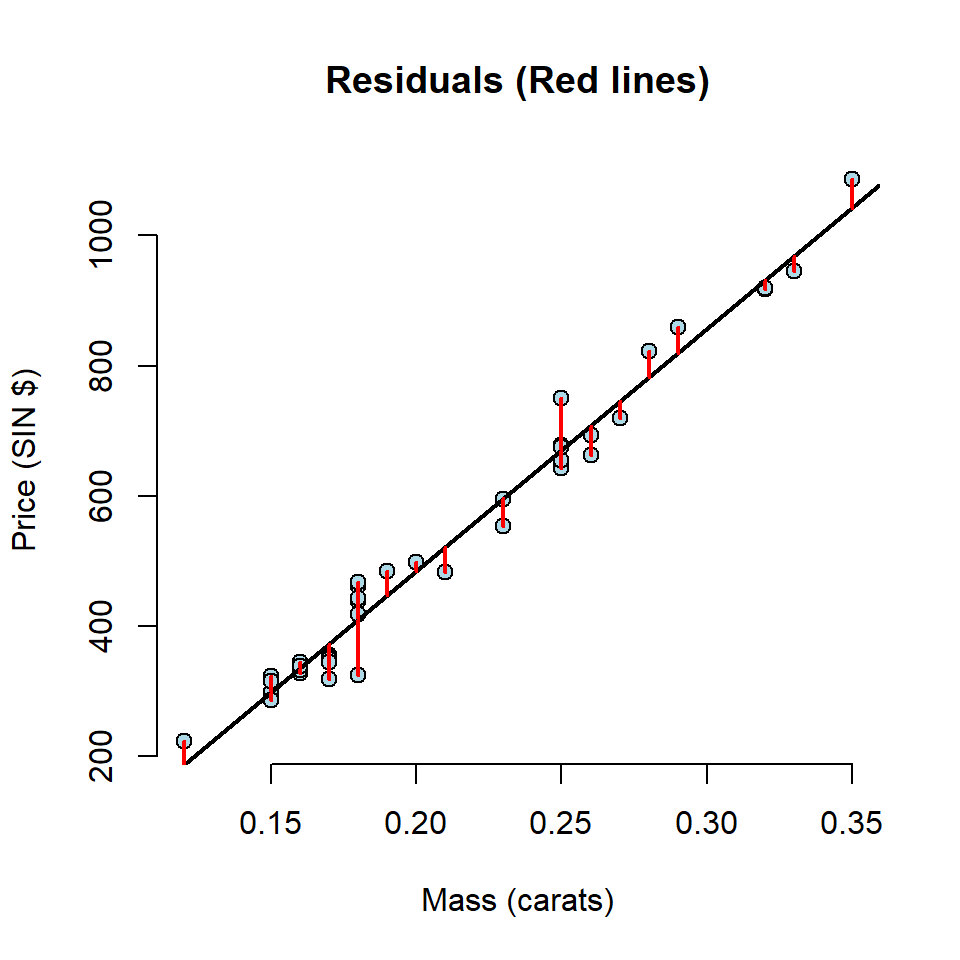

## **Residuals versus X**

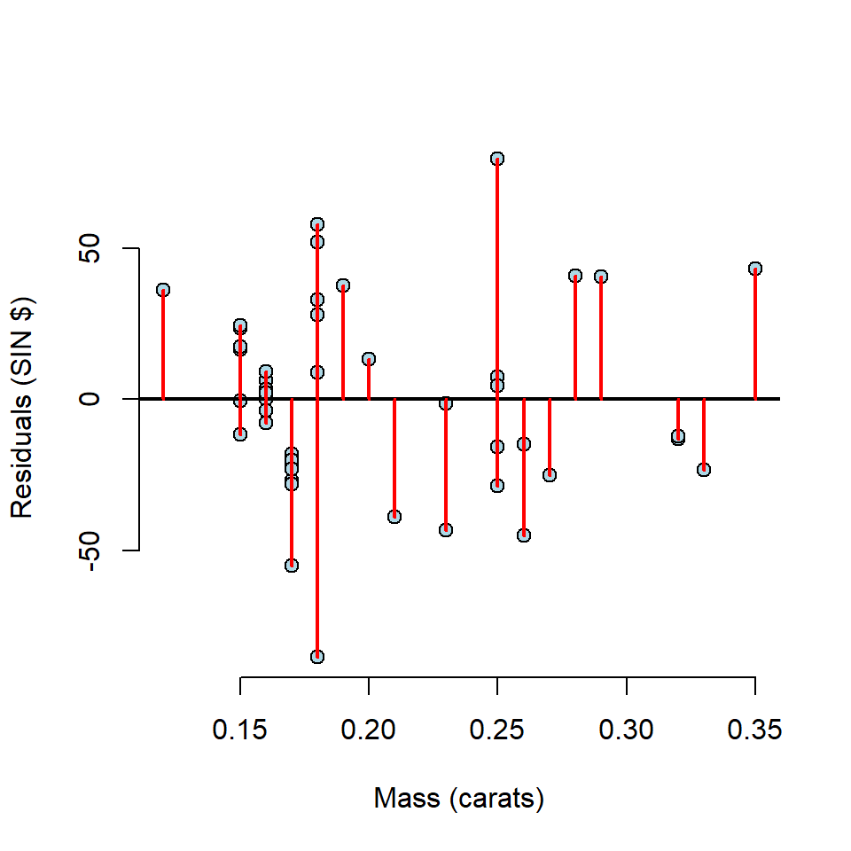

- Looking for any pattern (there should be none ideally). And if intercept is included then $\sum Residuals = 0$ i.e, points should be above and below the 0 line.
- The data is more spread at the regions with lot of data points if it’s plotted this way.
- Non linearity is well visualised using this plot.
- Heteroskedasticity is captured by this plot only.

## Residual variation

- Model $Y_i = \beta_0 + \beta_1 X_i + \epsilon_i$ where $\epsilon_i \sim N(0, \sigma^2)$.
- The ML estimate of $\sigma^2$ is $\frac{1}{n}\sum_{i=1}^n e_i^2$, the average squared residual. Thus the variance of the residual is the avg. of the squares.
- Most people use
  $$\hat \sigma^2 = \frac{1}{n-2}\sum_{i=1}^n e_i^2$$
- The $n-2$ instead of $n$ is so that $E[\hat \sigma^2] = \sigma^2$

```r
y <- diamond$price; x <- diamond$carat; n <- length(y)
fit <- lm(y ~ x)
e <- resid(fit)

summary(fit)$sigma # Direct method
```

```
## [1] 31.84052
```

```r
Res_Var <- sum(e^2) / (n-2)
sqrt(Res_Var) # Manually
```

```
## [1] 31.84052
```

## Summarizing variation

- Proof;
  $$\sum_{i=1}^n (Y_i - \bar Y)^2 = \sum_{i=1}^n (Y_i - \hat Y_i + \hat Y_i - \bar Y)^2 = \sum_{i=1}^n (Y_i - \hat Y_i)^2 +
  2 \sum_{i=1}^n (Y_i - \hat Y_i)(\hat Y_i - \bar Y) +
  \sum_{i=1}^n (\hat Y_i - \bar Y)^2$$
- Therefore, $\sum_{i=1}^n (Y_i - \bar Y)^2 = \sum_{i=1}^n (Y_i - \hat Y_i)^2 + \sum_{i=1}^n (\hat Y_i - \bar Y)^2$
- Or we can say that,
  - **Total Variation = Residual Variation (Unexplained variation) + Regression Variation (Variation explained by regressor)**
- Define the percent of total varation described by the model as $R^2$,
  $$R^2 = \frac{\sum_{i=1}^n (\hat Y_i - \bar Y)^2}{\sum_{i=1}^n (Y_i - \bar Y)^2} = 1 - \frac{\sum_{i=1}^n (Y_i - \hat Y_i)^2}{\sum_{i=1}^n (Y_i - \bar Y)^2}$$

## Some facts

- $R^2$ is the percentage of variation explained by the regression model.
- $0 \leq R^2 \leq 1$
- $R^2$ is the sample correlation squared.
- $R^2$ can be a misleading summary of model fit.
  - Deleting data can inflate $R^2$.
  - (For later.) Adding terms to a regression model always increases $R^2$.
- Do `example(anscombe)` to see the following data.
  - Basically same mean and variance of X and Y.
  - Identical correlations (hence same $R^2$ ).
  - Same linear regression relationship.

### Anscombe dataset ; Equivalent $R^2$, Mean & Variance between 4 datasets. But the fit is diff.

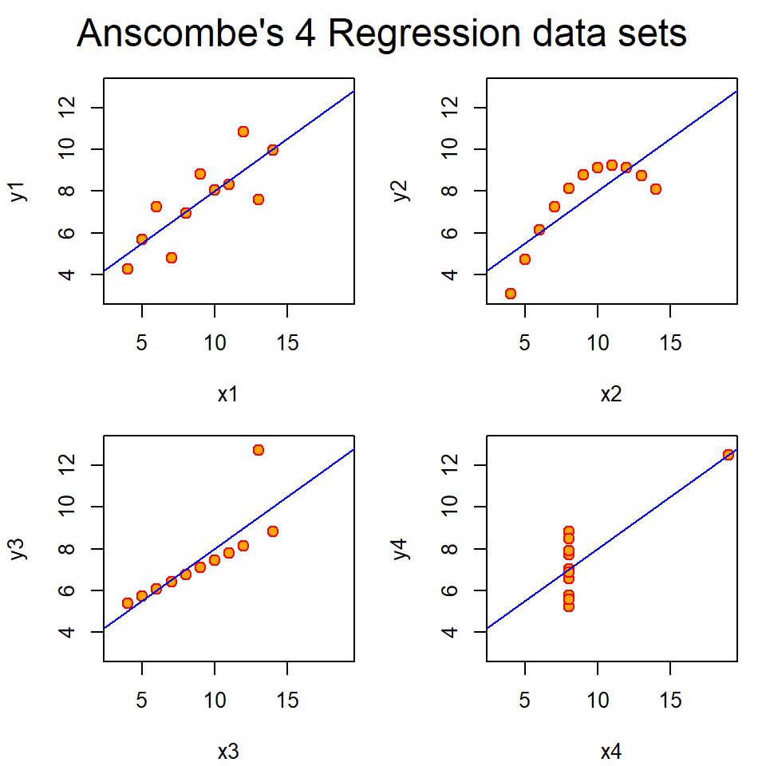

## Inference in regression

### Review

- Statistics like $\frac{\hat \theta - \theta}{\hat \sigma_{\hat \theta}}$ often have the following properties.
  1. Is normally distributed and has a finite sample Student’s T distribution if the estimated variance is replaced with a sample estimate (under normality assumptions).
  2. Can be used to test $H_0 : \theta = \theta_0$ versus $H_a : \theta >, <, \neq \theta_0$.
  3. Can be used to create a confidence interval for $\theta$ via $\hat \theta \pm Q_{1-\alpha/2} \hat \sigma_{\hat \theta}$ where $Q_{1-\alpha/2}$ is the relevant quantile from either a normal or T distribution.

## Results

```r
y <- diamond$price; x <- diamond$carat; n <- length(y)
beta1 <- cor(y,x) * (sd(y)/sd(x))   # Slope
beta0 <- mean(y) - beta1* mean(x)   # Intercept
e <- y - (beta0 + beta1*x)          # Residuals
sigma <- sqrt(sum(e^2) / (n-2))     # Residual std. error

ssx <- sum((x - mean(x))^2)

# Std errors for coefficients
seBeta0 <- (1 / n + mean(x) ^ 2 / ssx) ^ .5 * sigma
seBeta1 <- sigma / sqrt(ssx)

# T statistic
tBeta0 <- beta0 / seBeta0
tBeta1 <- beta1 / seBeta1

# P value
pBeta0 <- 2 * pt(abs(tBeta0), df = n - 2, lower.tail = FALSE)
pBeta1 <- 2 * pt(abs(tBeta1), df = n - 2, lower.tail = FALSE)

# Final table manually calculated
coefTable <- rbind(c(beta0, seBeta0, tBeta0, pBeta0), c(beta1, seBeta1, tBeta1, pBeta1))
colnames(coefTable) <- c("Estimate", "Std. Error", "t value", "P(>|t|)")
rownames(coefTable) <- c("(Intercept)", "x")

fit <- lm(y ~ x)
coefTable # Final table manually calculated
```

```
##              Estimate Std. Error   t value      P(>|t|)
## (Intercept) -259.6259   17.31886 -14.99094 2.523271e-19
## x           3721.0249   81.78588  45.49715 6.751260e-40
```

```r
summary(fit)$coefficients # Final table by lm()
```

```
##              Estimate Std. Error   t value     Pr(>|t|)
## (Intercept) -259.6259   17.31886 -14.99094 2.523271e-19
## x           3721.0249   81.78588  45.49715 6.751260e-40
```

## Getting a confidence interval

```r
sumCoef <- summary(fit)$coefficients
sumCoef[1,1] + c(-1, 1) * qt(.975, df = fit$df) * sumCoef[1, 2]
```

```
## [1] -294.4870 -224.7649
```

```r
sumCoef[2,1] + c(-1, 1) * qt(.975, df = fit$df) * sumCoef[2, 2]
```

```
## [1] 3556.398 3885.651
```

With 95% confidence, we estimate that a 0.1 carat increase in diamond size results in a 355.6 to 388.6 increase in price in (Singapore) dollars.

## Relation between $R^2$ and $r$ (the corrrelation)

Recall that $(\hat Y_i - \bar Y) = \hat \beta_1 (X_i - \bar X)$ so that
$$R^2 = \frac{\sum_{i=1}^n (\hat Y_i - \bar Y)^2}{\sum_{i=1}^n (Y_i - \bar Y)^2}
= \hat \beta_1^2 \frac{\sum_{i=1}^n(X_i - \bar X)}{\sum_{i=1}^n (Y_i - \bar Y)^2}
= Cor(Y, X)^2$$
Since, recall,
$$\hat \beta_1 = Cor(Y, X)\frac{Sd(Y)}{Sd(X)}$$
So, $R^2$ is literally $r$ squared.

## Introducing spline terms for better fit

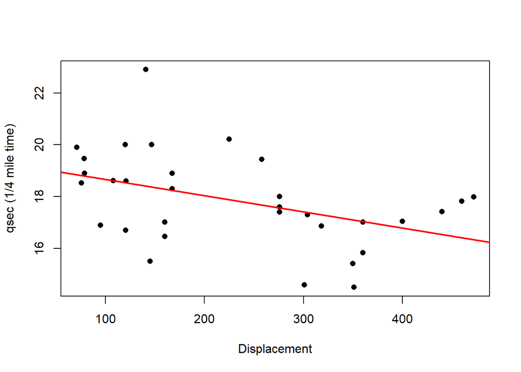

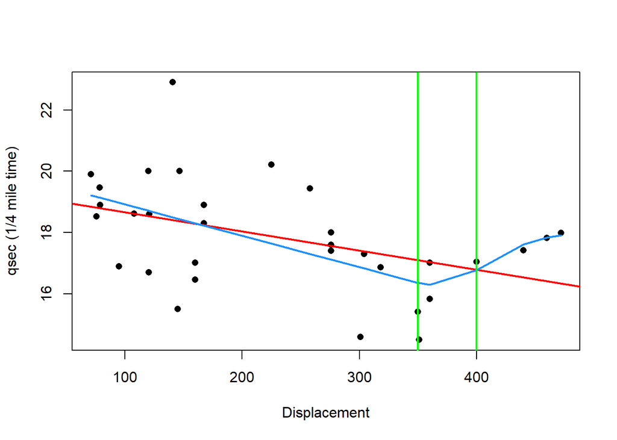

```r
x <- mtcars[order(mtcars$disp),]

# Knot terms
knots <- c(350, 400)
splineTerms1 <- sapply(knots, function(knot){ifelse(x$disp - knot > 0, (x$disp - knot)^2, 0) })

xMat <- cbind(Intercept = 1, Displacement = x$disp, splineTerms1 )
colnames(xMat) <- c( "Intercept", "Displacement", "Knot1", "Knot2")

# model fitting
fit1 <- lm(qsec ~ disp, x)
fit2 <- lm(x$qsec ~ xMat-1)
yhat <- predict(fit2)

#Df <- data.frame(x = x$disp, y = x$qsec, yhat, fitted(fit1) )

# Plotting
plot(mtcars$disp, mtcars$qsec, pch = 16, xlab = "Displacement", ylab = "qsec (1/4 mile time)" )
abline(fit1, col="red", lwd = 2)
lines(x$disp, yhat, lwd = 2, col = "dodgerblue")
abline(v = knots, lwd = 2, col="green")
```

- We can see that adding 2 knots has clearly given a better fit to the data.